# Mortgage Payment and Default

# 1 Descriptive Statistics

## 1.1 10% Negative Equity Loans

```
##
## ====================================================================
## Statistic       Mean      St. Dev.  Pctl(25) Median  Pctl(75)   N
## --------------------------------------------------------------------
## def             0.039      0.194       0        0       0     63,151
## mpay_value      0.007      0.001     0.007    0.007   0.008   63,151
## rent_value      0.009      0.003     0.008    0.009   0.010   63,151
## fico           724.929     53.744     687      730     769    63,089
## ltv            80.898      10.394      75      80       90    63,151
## dti            37.419      11.891      29      37       46    61,787
## upb          192,877.200 82,109.450 133,000  178,000 241,000  63,151
## interestrate    6.111      0.566     5.750    6.125   6.500   63,151
## org_year      2,006.666    1.451     2,005    2,007   2,008   63,151
## ne_year       2,011.266    1.058     2,011    2,011   2,011   63,151
## --------------------------------------------------------------------
##
```

## 1.2 10% Positive Eqity Loans

```
##
## ====================================================================
## Statistic       Mean      St. Dev.  Pctl(25) Median  Pctl(75)   N
## --------------------------------------------------------------------
## def             0.020      0.139       0        0       0     47,591
## mpay_value      0.006      0.001     0.005    0.006   0.006   47,591
## rent_value      0.008      0.002     0.006    0.007   0.008   47,591
## fico           740.228     51.608     706      750     782    47,545
## ltv            77.994      8.847       75      80       80    47,591
## dti            35.211      11.846      27      35       44    46,980
## upb          187,173.400 88,007.920 120,000  170,000 240,000  47,591
## interestrate    5.630      0.701     5.000    5.625   6.125   47,591
## org_year      2,007.345    2.148     2,006    2,008   2,009   47,591
## ne_year       2,010.946    0.545     2,011    2,011   2,011   47,591
## --------------------------------------------------------------------
##
```

Back to top

# 2 Negative Equity: Default ~ Mortgage-to-value + rent-to-value

- Sample: Loan enters in to the sample after borrower reaching the particular negative equity threshold and the default indicates whether borrower defaulted in the following 12 months after reaching the negative equity threshold.
- mtg30us: 30-Year Fixed Rate Mortgage Average in the United States in the loan origination month
- interest_diff: interest rate - mtg30us
- rent-to-value : median rent/median value for the zip code in the negative equity quarter

## 2.1 Negative Equity: First Stage

```
##
## ==============================================================
##                                    Dependent variable:
##                            -----------------------------------
##                                    first_stage_formula
##                              10% NE      30% NE      50% NE
##                                (1)         (2)         (3)
## --------------------------------------------------------------
## mtg30us                     0.001***    0.001***    0.001***
##                             (0.00001)   (0.00001)   (0.00002)
## fico                       -0.00000*** -0.00000*** -0.00000***
##                             (0.00000)   (0.00000)   (0.00000)
## log(current_housevalue)     -0.007***   -0.008***   -0.009***
##                             (0.00004)   (0.0001)    (0.0002)
## ltv                        0.00001***  0.00001***  0.00001***
##                             (0.00000)   (0.00000)   (0.00000)
## dti                        0.00000***   0.00000*    -0.00000
##                             (0.00000)   (0.00000)   (0.00000)
## log(upb)                    0.007***    0.008***    0.008***
##                             (0.00004)   (0.0001)    (0.0002)
## Constant                    0.004***    0.004***    0.003***
##                             (0.0002)    (0.0002)    (0.0003)
## --------------------------------------------------------------
## loan purpose                   Yes         Yes         Yes
## occupancy                      Yes         Yes         Yes
## zip * negative equity year     Yes         Yes         Yes
## zip * origination year         Yes         Yes         Yes
## --------------------------------------------------------------
## Observations                 61,726      29,145      11,987
## Adjusted R2                   0.788       0.645       0.534
## ==============================================================
## Note:                              *p<0.1; **p<0.05; ***p<0.01
```

Back to top

## 2.2 Negative Equity: IV Regressions

```
##
## ======================================================================
##                                        Dependent variable:
##                            -------------------------------------------
##                                                def
##                            OLS 10% NE IV 10% NE  IV 30% NE  IV 50% NE
##                               (1)        (2)        (3)        (4)
## ----------------------------------------------------------------------
## mpay_value                 14.856***  23.748***   19.595**  58.278***
##                             (2.440)    (6.922)    (9.834)    (13.237)
## fico                       -0.0002*** -0.0002*** -0.0001*** -0.0002***
##                            (0.00001)  (0.00002)  (0.00002)  (0.00004)
## ltv                         0.001***   0.001***   0.003***   0.007***
##                             (0.0002)   (0.0002)   (0.0004)   (0.001)
## dti                        0.0003***  0.0003***  0.0005***  0.0005***
##                             (0.0001)   (0.0001)   (0.0001)   (0.0002)
## log(upb)                    0.541***   0.484***   1.310***   1.125***
##                             (0.032)    (0.053)    (0.086)    (0.131)
## log(current_housevalue)    -0.537***  -0.479***  -1.304***  -1.105***
##                             (0.033)    (0.053)    (0.088)    (0.133)
## Constant                    -0.228*    -0.302**  -0.922***  -1.984***
##                             (0.130)    (0.140)    (0.131)    (0.199)
## ----------------------------------------------------------------------
## loan purpose                  Yes        Yes        Yes        Yes
## occupancy                     Yes        Yes        Yes        Yes
## zip * negative equity year    Yes        Yes        Yes        Yes
## zip * origination year        Yes        Yes        Yes        Yes
## ----------------------------------------------------------------------
## Observations                 61,726     61,726     29,145     11,987
## Adjusted R2                  0.168      0.167      0.231      0.370
## ======================================================================
## Note:                                      *p<0.1; **p<0.05; ***p<0.01
```

Back to top

## 2.3 Univariate Evidence (30% Negative equity sample)

- FE adjusted mortgage-to-value = mortgage-to-value - predicted mortgage-to-value from (mortgage-to-value~ zip * ne year + zip * org year)
- Results are similar for other levels of negative equity

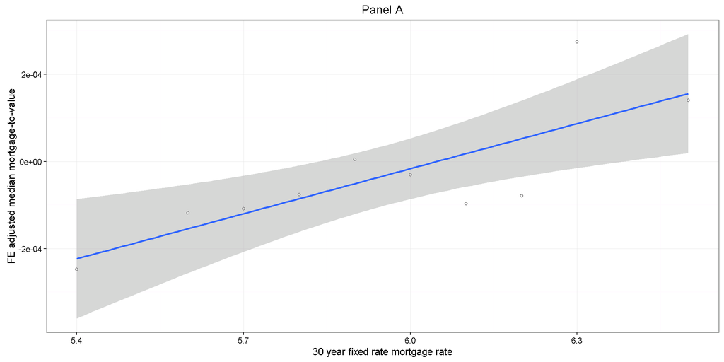

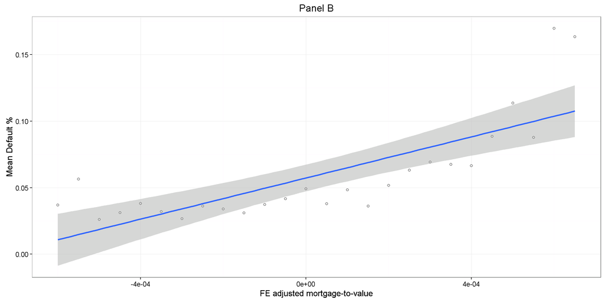

Back to top

## 2.4 Negative Equity: IV Regressions (Split by rent-to-value)

- Less than median: Loans from zip codes where median rent-to-value is less than the median(rent-to-value) in the same quarter
- Greater than median: Loans from zip codes where median rent-to-value is greater than the median(rent-to-value) in the same quarter

```
##
## ==========================================================================================================================
##                                                                  Dependent variable:
##                            -----------------------------------------------------------------------------------------------
##                                                                          def
##                            10% NE (rv<med) 10% NE (rv>med) 30% NE (rv<med) 30% NE (rv>med) 50% NE (rv<med) 50% NE (rv>med)
##                                  (1)             (2)             (3)             (4)             (5)             (6)
## --------------------------------------------------------------------------------------------------------------------------
## mpay_value                    26.629**         13.853*        48.724***        -5.015         92.727***        12.720
##                               (11.149)         (8.002)        (14.230)        (12.499)        (17.644)        (17.590)
## fico                         -0.0002***      -0.0002***      -0.0001***      -0.0002***      -0.0001***      -0.0002***
##                               (0.00003)       (0.00002)       (0.00004)       (0.00003)       (0.00005)       (0.00005)
## ltv                           0.002***        0.001***        0.004***        0.002***        0.008***        0.004***
##                               (0.0004)        (0.0002)         (0.001)        (0.0005)         (0.001)         (0.001)
## dti                           0.0005***       0.0002***       0.001***         0.0002         0.0005**         0.0004*
##                               (0.0001)        (0.0001)        (0.0001)        (0.0001)        (0.0002)        (0.0002)
## log(upb)                       0.198**        0.648***        1.135***        1.632***        0.698***        1.709***
##                                (0.083)         (0.062)         (0.127)         (0.107)         (0.172)         (0.177)
## log(current_housevalue)       -0.188**        -0.647***       -1.117***       -1.636***       -0.661***       -1.708***
##                                (0.084)         (0.063)         (0.129)         (0.108)         (0.174)         (0.180)
## Constant                      0.627***         -0.195         -1.345***       -0.552***       -2.476***       -1.265***
##                                (0.210)         (0.134)         (0.251)         (0.143)         (0.231)         (0.194)
## --------------------------------------------------------------------------------------------------------------------------
## loan purpose                     Yes             Yes             Yes             Yes             Yes             Yes
## occupancy                        Yes             Yes             Yes             Yes             Yes             Yes
## zip * negative equity year       Yes             Yes             Yes             Yes             Yes             Yes
## zip * origination year           Yes             Yes             Yes             Yes             Yes             Yes
## --------------------------------------------------------------------------------------------------------------------------
## Observations                   24,351          37,375          15,065          14,080           6,571           5,416
## Adjusted R2                     0.297           0.237           0.276           0.328           0.448           0.458
## ==========================================================================================================================
## Note:                                                                                          *p<0.1; **p<0.05; ***p<0.01
```

Back to top

## 2.5 Negative Equity: IV Regressions (Split by mortgage-to-rent)

- Less than median: Loans from zip codes where median mortgage-to-rent is less than the median(mortgage-to-rent) in the same quarter
- Greater than median: Loans from zip codes where median mortgage-to-rent is greater than the median(mortgage-to-rent) in the same quarter

```
##
## ==========================================================================================================================
##                                                                  Dependent variable:
##                            -----------------------------------------------------------------------------------------------
##                                                                          def
##                            10% NE (mr<med) 10% NE (mr>med) 30% NE (mr<med) 30% NE (mr>med) 50% NE (mr<med) 50% NE (mr>med)
##                                  (1)             (2)             (3)             (4)             (5)             (6)
## --------------------------------------------------------------------------------------------------------------------------
## mpay_value                    19.090**          5.791           0.852         58.934***        14.402         88.095***
##                                (7.768)        (11.023)        (11.187)        (15.782)        (18.993)        (16.292)
## fico                         -0.0002***      -0.0002***      -0.0001***      -0.0001***      -0.0002***       -0.0001**
##                               (0.00002)       (0.00002)       (0.00003)       (0.00004)       (0.0001)        (0.00004)
## ltv                           0.001***         0.001**        0.002***        0.003***        0.004***        0.009***
##                               (0.0002)        (0.0004)        (0.0004)         (0.001)         (0.001)         (0.001)
## dti                           0.0002***       0.0004***        0.0002*        0.001***         0.0002         0.0004**
##                               (0.0001)        (0.0001)        (0.0001)        (0.0002)        (0.0002)        (0.0002)
## log(upb)                      0.684***          0.084         1.528***        1.311***        1.561***        0.969***
##                                (0.060)         (0.082)         (0.097)         (0.139)         (0.190)         (0.162)
## log(current_housevalue)       -0.682***        -0.078         -1.532***       -1.285***       -1.557***       -0.937***
##                                (0.061)         (0.083)         (0.098)         (0.142)         (0.192)         (0.165)
## Constant                       -0.256*        0.932***        -0.558***       -1.530***       -1.214***       -2.616***
##                                (0.132)         (0.203)         (0.131)         (0.264)         (0.203)         (0.219)
## --------------------------------------------------------------------------------------------------------------------------
## loan purpose                     Yes             No              Yes             Yes             Yes             Yes
## occupancy                        Yes             No              Yes             Yes             Yes             Yes
## zip * negative equity year       Yes             Yes             Yes             Yes             Yes             Yes
## zip * origination year           Yes             Yes             Yes             Yes             Yes             Yes
## --------------------------------------------------------------------------------------------------------------------------
## Observations                   39,507          22,219          16,245          12,900           5,295           6,692
## Adjusted R2                     0.251           0.375           0.350           0.293           0.428           0.479
## ==========================================================================================================================
## Note:                                                                                          *p<0.1; **p<0.05; ***p<0.01
```

Back to top

# 3 Positive Equity: Default ~ Mortgage-to-value + rent-to-value

- Sample: Loan enters in to the sample after borrower reaching the particular positive equity threshold and the default indicates whether borrower defaulted in the following 12 months after reaching the negative equity threshold.
- mtg30us: 30-Year Fixed Rate Mortgage Average in the United States in the loan origination month
- interest_diff: interest rate - mtg30us
- rent-to-value : median rent/median value for the zip code in the negative equity quarter

## 3.1 Positive Equity: First Stage

```
##
## ==============================================================
##                                    Dependent variable:
##                            -----------------------------------
##                                    first_stage_formula
##                              10% PE      30% PE      50% PE
##                                (1)         (2)         (3)
## --------------------------------------------------------------
## mtg30us                     0.0004***   0.0002***   0.0002***
##                             (0.00001)   (0.00000)   (0.00000)
## fico                       -0.00000*** -0.00000*** -0.00000***
##                             (0.00000)   (0.00000)   (0.00000)
## log(current_housevalue)     -0.005***   -0.005***   -0.004***
##                             (0.00004)   (0.00003)   (0.00002)
## ltv                        0.00001***  0.00000***   0.00000**
##                             (0.00000)   (0.00000)   (0.00000)
## dti                        0.00000***  0.00000***  0.00000***
##                             (0.00000)   (0.00000)   (0.00000)
## log(upb)                    0.005***    0.005***    0.004***
##                             (0.00004)   (0.00003)   (0.00002)
## Constant                    0.006***    0.006***    0.006***
##                             (0.0002)    (0.0002)    (0.0001)
## --------------------------------------------------------------
## loan purpose                   Yes         No          No
## occupancy                      Yes         No          No
## zip * negative equity year     Yes         Yes         Yes
## zip * origination year         Yes         Yes         Yes
## --------------------------------------------------------------
## Observations                 46,934      40,669      39,045
## Adjusted R2                   0.872       0.931       0.946
## ==============================================================
## Note:                              *p<0.1; **p<0.05; ***p<0.01
```

Back to top

## 3.2 Positive Equity: IV Regressions

```
##
## ============================================================================================
##                                                   Dependent variable:
##                            -----------------------------------------------------------------
##                                                           def
##                            OLS 10% PE IV 10% PE  IV 30% PE  IV 50% PE  IV 70% PE  IV 90% PE
##                               (1)        (2)        (3)        (4)        (5)        (6)
## --------------------------------------------------------------------------------------------
## mpay_value                 20.467***    10.294    24.038*     5.351      13.082     7.773
##                             (2.654)    (7.949)    (12.289)   (12.164)   (16.831)   (14.550)
## fico                       -0.0002*** -0.0002*** -0.0002*** -0.0002*** -0.0002*** -0.0001***
##                            (0.00001)  (0.00002)  (0.00001)  (0.00001)  (0.00001)  (0.00002)
## ltv                         0.002***   0.002***   0.001***   0.001***   -0.0003    -0.0004
##                             (0.0002)   (0.0002)   (0.0002)   (0.0002)   (0.0003)   (0.001)
## dti                        0.0004***  0.0004***  0.0001***  0.0001***  0.0002***   0.00001
##                             (0.0001)   (0.0001)  (0.00005)  (0.00004)   (0.0001)   (0.0001)
## log(upb)                    0.424***   0.478***   -0.121**    -0.058     -0.034     -0.009
##                             (0.028)    (0.049)    (0.059)    (0.053)    (0.059)    (0.009)
## log(current_housevalue)    -0.421***  -0.477***   0.122**     0.057      0.031      0.007
##                             (0.028)    (0.050)    (0.060)    (0.054)    (0.060)    (0.009)
## Constant                     -0.163     -0.081     -0.082     0.050      0.083      0.080*
##                             (0.143)    (0.155)    (0.152)    (0.121)    (0.156)    (0.042)
## --------------------------------------------------------------------------------------------
## loan purpose                  Yes        Yes         No         No         No         No
## occupancy                     Yes        Yes         No         No         No         No
## zip * negative equity year    Yes        Yes        Yes        Yes        Yes        Yes
## zip * origination year        Yes        Yes        Yes        Yes        Yes        Yes
## --------------------------------------------------------------------------------------------
## Observations                 46,934     46,934     40,669     39,045     23,399     4,297
## Adjusted R2                  0.170      0.169      0.137      0.104      0.125      0.255
## ============================================================================================
## Note:                                                            *p<0.1; **p<0.05; ***p<0.01
```

Back to top

## 3.3 Positive Equity: IV Regressions (Split by rent-to-value)

- Less than median: Loans from zip codes where median rent-to-value is less than the median(rent-to-value) in the same quarter
- Greater than median: Loans from zip codes where median rent-to-value is greater than the median(rent-to-value) in the same quarter

```
##
## ==========================================================================================================================================================
##                                                                                  Dependent variable:
##                            -------------------------------------------------------------------------------------------------------------------------------
##                                                                                          def
##                            10% PE (rv<med) 10% PE (rv>med) 30% PE (rv<med) 30% PE (rv>med) 50% PE (rv<med) 50% PE (rv>med) 70% PE (rv<med) 70% PE (rv>med)
##                                  (1)             (2)             (3)             (4)             (5)             (6)             (7)             (8)
## ----------------------------------------------------------------------------------------------------------------------------------------------------------
## mpay_value                    29.460***        -5.728          17.663          11.449          -7.324           7.317           2.832          30.052
##                               (10.784)        (10.392)        (16.645)        (16.800)        (18.654)        (14.736)        (23.825)        (22.701)
## fico                         -0.0001***      -0.0001***      -0.0002***      -0.0002***      -0.0002***      -0.0001***      -0.0002***      -0.0001***
##                               (0.00002)       (0.00002)       (0.00002)       (0.00002)       (0.00002)       (0.00001)       (0.00002)       (0.00002)
## ltv                           0.002***        0.001***         0.001*         0.001***        0.002***         0.0001          -0.001          -0.0002
##                               (0.0003)        (0.0002)        (0.0004)        (0.0003)        (0.0005)        (0.0003)         (0.001)        (0.0003)
## dti                           0.0003***       0.0004***        0.0001         0.0002**        0.0002***        0.0001          0.0001         0.0002***
##                               (0.0001)        (0.0001)        (0.0001)        (0.0001)        (0.0001)        (0.0001)        (0.0001)        (0.0001)
## log(upb)                      0.570***        0.436***         -0.010          -0.099          -0.073          -0.040           0.029          -0.112
##                                (0.064)         (0.065)         (0.074)         (0.083)         (0.076)         (0.066)         (0.073)         (0.085)
## log(current_housevalue)       -0.563***       -0.440***         0.011           0.098           0.070           0.039          -0.034           0.110
##                                (0.065)         (0.067)         (0.075)         (0.084)         (0.077)         (0.067)         (0.074)         (0.087)
## Constant                      -0.302**          0.091           0.018          -0.015           0.030           0.059           0.223          -0.074
##                                (0.126)         (0.156)         (0.171)         (0.176)         (0.184)         (0.143)         (0.182)         (0.181)
## ----------------------------------------------------------------------------------------------------------------------------------------------------------
## loan purpose                     Yes             No              No              No              No              No              No              No
## occupancy                        Yes             No              No              No              No              No              No              No
## zip * negative equity year       Yes             Yes             Yes             Yes             Yes             Yes             Yes             Yes
## zip * origination year           Yes             Yes             Yes             Yes             Yes             Yes             Yes             Yes
## ----------------------------------------------------------------------------------------------------------------------------------------------------------
## Observations                   22,495          24,439          19,028          21,641          18,474          20,571          11,225          12,174
## Adjusted R2                     0.306           0.274           0.259           0.217           0.219           0.163           0.224           0.144
## ==========================================================================================================================================================
## Note:                                                                                                                          *p<0.1; **p<0.05; ***p<0.01
```

Back to top

## 3.4 Positive Equity: IV Regressions (Split by mortgage-to-rent)

- Less than median: Loans from zip codes where median mortgage-to-rent is less than the median(mortgage-to-rent) in the same quarter
- Greater than median: Loans from zip codes where median mortgage-to-rent is greater than the median(mortgage-to-rent) in the same quarter

```
##
## ==========================================================================================================================================================
##                                                                                  Dependent variable:
##                            -------------------------------------------------------------------------------------------------------------------------------
##                                                                                          def
##                            10% PE (mr<med) 10% PE (mr>med) 30% PE (mr<med) 30% PE (mr>med) 50% PE (mr<med) 50% PE (mr>med) 70% PE (mr<med) 70% PE (mr>med)
##                                  (1)             (2)             (3)             (4)             (5)             (6)             (7)             (8)
## ----------------------------------------------------------------------------------------------------------------------------------------------------------
## mpay_value                     -13.562        28.667***         7.128          26.624           4.449           9.391          24.539          -8.576
##                               (10.595)        (10.553)        (16.916)        (16.612)        (14.911)        (19.448)        (20.690)        (27.349)
## fico                         -0.0001***      -0.0001***      -0.0002***      -0.0002***      -0.0002***      -0.0002***      -0.0002***      -0.0001***
##                               (0.00002)       (0.00002)       (0.00002)       (0.00002)       (0.00001)       (0.00002)       (0.00002)       (0.00002)
## ltv                           0.001***        0.001***        0.001***          0.001          0.0004         0.001***        -0.00005         -0.0002
##                               (0.0002)        (0.0003)        (0.0003)        (0.0004)        (0.0003)        (0.0004)        (0.0003)         (0.001)
## dti                           0.0004***       0.0003***       0.0002**         0.0001*         0.00001        0.0003***       0.0002***       0.0002**
##                               (0.0001)        (0.0001)        (0.0001)        (0.0001)        (0.0001)        (0.0001)        (0.0001)        (0.0001)
## log(upb)                      0.487***        0.633***         -0.066          -0.051          -0.044          -0.107          -0.093           0.043
##                                (0.066)         (0.063)         (0.080)         (0.076)         (0.064)         (0.082)         (0.073)         (0.087)
## log(current_housevalue)       -0.491***       -0.626***         0.064           0.052           0.044           0.105           0.089          -0.048
##                                (0.067)         (0.064)         (0.082)         (0.078)         (0.066)         (0.084)         (0.075)         (0.089)
## Constant                        0.140         -0.252**          0.036          -0.034           0.047           0.009          -0.023           0.243
##                                (0.159)         (0.123)         (0.175)         (0.172)         (0.132)         (0.181)         (0.175)         (0.195)
## ----------------------------------------------------------------------------------------------------------------------------------------------------------
## loan purpose                     Yes             Yes             No              No              No              No              No              No
## occupancy                        Yes             Yes             No              No              No              No              No              No
## zip * negative equity year       Yes             Yes             Yes             Yes             Yes             Yes             Yes             Yes
## zip * origination year           Yes             Yes             Yes             Yes             Yes             Yes             Yes             Yes
## ----------------------------------------------------------------------------------------------------------------------------------------------------------
## Observations                   24,193          22,741          21,996          18,673          22,133          16,912          13,795           9,604
## Adjusted R2                     0.280           0.305           0.206           0.262           0.164           0.195           0.141           0.235
## ==========================================================================================================================================================
## Note:                                                                                                                          *p<0.1; **p<0.05; ***p<0.01
```